# Análisis Exploratorio (EDA) – Landing Page

### Importación de paquetes

```python
# Importar Dependencias
%matplotlib inline

# Iniciar las importaciones de Python
import math, time, random, datetime

# Manipulación de Dato
import numpy as np
import pandas as pd

# Visualización
import matplotlib.pyplot as plt
import missingno
import seaborn as sns
plt.style.use('seaborn-whitegrid')

# Preprocesamiento
from sklearn.preprocessing import OneHotEncoder, LabelEncoder, label_binarize

# Selección de funciones y codificación
from sklearn.feature_selection import RFE, RFECV
from sklearn.svm import SVR
from sklearn.decomposition import PCA
import sklearn.ensemble as ske
from sklearn import datasets, model_selection, tree, preprocessing, metrics, linear_model
from mpl_toolkits.mplot3d import Axes3D
from sklearn.ensemble import RandomForestClassifier, GradientBoostingClassifier
from sklearn.linear_model import LinearRegression, LogisticRegression, Ridge, Lasso, SGDClassifier

import warnings
warnings.filterwarnings('ignore')
```

#### Cargando los datos

```python
df = pd.read_csv("C:/Users/Jesus/Documents/LOANDING1.csv", sep = ";")
```

```python
df.head()
```

|  | campaing_trafficSource_id | landing_page_groups_id | traffic_source_id | visitor_device_browser | visitor_device_hardware_family | visitor_device_hardware_model | visitor_device_hardware_vendor | visitor_device_os_family | visitor_device_os_vendor | visitor_device_os_version | visitor_device_type | visitor_geo_location_cityName | visitor_geo_location_connection_type | visitor_geo_location_countryCode | visitor_geo_location_isp | visitor_geo_location_regionName | landing_page_id |
| --- | --- | --- | --- | --- | --- | --- | --- | --- | --- | --- | --- | --- | --- | --- | --- | --- | --- |
| 0 | 57ac89e0a38746122f4af882 | 5cf18750f2ced40c7112e778 | 57ac89e0a38746122f4af882 | Edge | Emulator | Unknown | Unknown | Windows | Microsoft | 10.0 | Desktop | Gosport | Cable/DSL | GB | BT | England | 5cf1868af2ced40c7112e777 |
| 1 | 57ac89e0a38746122f4af882 | 5cf18750f2ced40c7112e778 | 57ac89e0a38746122f4af882 | Chrome | Emulator | Unknown | Unknown | Windows | Microsoft | 7 | Desktop | Kings Lynn | Cable/DSL | GB | BT | England | 5cad22e04a341c22c95298e6 |
| 2 | 57ac89e0a38746122f4af882 | 5cf18750f2ced40c7112e778 | 57ac89e0a38746122f4af882 | Edge | Emulator | Unknown | Unknown | Windows | Microsoft | 10.0 | Desktop | Stockport | Cable/DSL | GB | Daisy Communications Ltd | England | 5cad22e04a341c22c95298e6 |
| 3 | 57ac89e0a38746122f4af882 | 5cf18750f2ced40c7112e778 | 57ac89e0a38746122f4af882 | Edge | Emulator | Unknown | Unknown | Windows | Microsoft | 10.0 | Desktop | Croydon | Cable/DSL | GB | Virgin Media | England | 5cf1868af2ced40c7112e777 |
| 4 | 57ac89e0a38746122f4af882 | 5cf18750f2ced40c7112e778 | 57ac89e0a38746122f4af882 | Edge | Emulator | Unknown | Unknown | Windows | Microsoft | 10.0 | Desktop | Birkenhead | Cable/DSL | GB | Eclipse Internet | England | 5cf1868af2ced40c7112e777 |

### Exploración de datos: Univariante

Al explorar nuestro conjunto de datos y sus características, tenemos muchas opciones disponibles para nosotros. Podemos explorar cada característica individualmente o comparar pares de características, encontrando la correlación entre ellas. Comencemos con un análisis simple Univariante (una característica).

Las características pueden ser de múltiples tipos:

- Nominal: es para categorías mutuas exclusivas, pero no ordenadas
- Ordinal: es aquel en el que importa el orden pero no la diferencia entre valores
- Intervalo: es una medida donde la diferencia entre dos valores es significativa.
- Ratio: tiene todas las propiedades de una variable de intervalo, y también tiene una definición clara de 0.0

Existen múltiples formas de manipular cada tipo de entidad, pero para simplificar, definiremos solo dos tipos de entidad:

```
* Numérico: cualquier característica que contiene valores numéricos.
* Categórico: cualquier característica que contenga categorías o texto.
```

```python
# Resumen de las estadísticas básicas
df.describe()
```

|  | campaing_trafficSource_id | landing_page_groups_id | traffic_source_id | visitor_device_browser | visitor_device_hardware_family | visitor_device_hardware_model | visitor_device_hardware_vendor | visitor_device_os_family | visitor_device_os_vendor | visitor_device_os_version | visitor_device_type | visitor_geo_location_cityName | visitor_geo_location_connection_type | visitor_geo_location_countryCode | visitor_geo_location_isp | visitor_geo_location_regionName | landing_page_id |
| --- | --- | --- | --- | --- | --- | --- | --- | --- | --- | --- | --- | --- | --- | --- | --- | --- | --- |
| count | 1744 | 1744 | 1744 | 1744 | 1744 | 1744 | 1744 | 1744 | 1744 | 1744 | 1744 | 1744 | 1744 | 1744 | 1744 | 1744 | 1744 |
| unique | 2 | 1 | 2 | 23 | 232 | 252 | 34 | 7 | 3 | 59 | 3 | 535 | 3 | 1 | 60 | 5 | 2 |
| top | 57ac89e0a38746122f4af882 | 5cf18750f2ced40c7112e778 | 57ac89e0a38746122f4af882 | Chrome Mobile | Emulator | Unknown | Apple | iOS | Apple | 12.3.1 | Phone | London | Cable/DSL | GB | BT | England | 5cf1868af2ced40c7112e777 |
| freq | 1520 | 1744 | 1520 | 489 | 455 | 456 | 672 | 645 | 672 | 450 | 985 | 104 | 1519 | 1744 | 417 | 1448 | 980 |

Todas las variables bajo estudio corresponden a variables categóricas.

### ¿Qué valores faltantes hay?

Estas son filas a las que les falta un valor o tienen NaN en lugar de algo como el resto de la columna.

```python
total = df.isnull().sum().sort_values(ascending = False)
percent = (df.isnull().sum() / df.isnull().count()).sort_values(ascending = False)
missing_data = pd.concat([total, percent], axis = 1, keys = ['Total', 'Percent'])
missing_data.head()
```

|  | Total | Percent |
| --- | --- | --- |
| landing_page_id | 0 | 0.0 |
| visitor_device_os_family | 0 | 0.0 |
| landing_page_groups_id | 0 | 0.0 |
| traffic_source_id | 0 | 0.0 |
| visitor_device_browser | 0 | 0.0 |

Según se aprecia en la tabla no existen valores faltantes ya que fueron previamente depurados. Del total de 2.000 fueron eliminados 256 datos ya que les faltaba un valor.

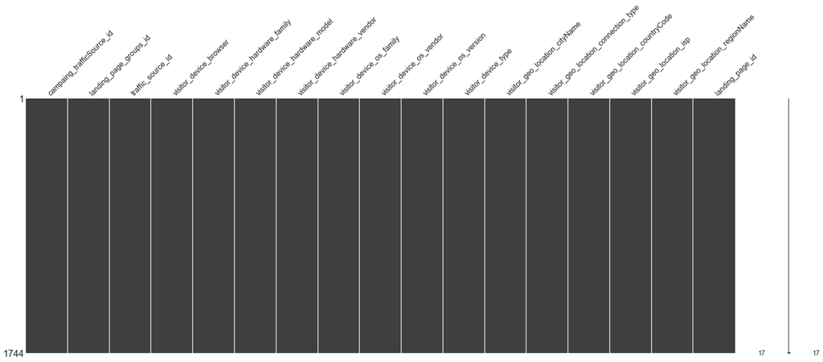

```python
# Gráfico de valores perdidos
missingno.matrix(df, figsize = (30,10))
```

```python
# Diferentes tipos de datos en el conjunto de datos
df.dtypes
```

```
campaing_trafficSource_id               object
landing_page_groups_id                  object
traffic_source_id                       object
visitor_device_browser                  object
visitor_device_hardware_family          object
visitor_device_hardware_model           object
visitor_device_hardware_vendor          object
visitor_device_os_family                object
visitor_device_os_vendor                object
visitor_device_os_version               object
visitor_device_type                     object
visitor_geo_location_cityName           object
visitor_geo_location_connection_type    object
visitor_geo_location_countryCode        object
visitor_geo_location_isp                object
visitor_geo_location_regionName         object
landing_page_id                         object
dtype: object
```

### Limpieza de características, ingeniería e imputación

Para limpiar nuestros datos, necesitaremos trabajar con: • Valores faltantes: Omita elementos de un conjunto de datos que contengan valores faltantes o los impute (complételos). • Valores especiales: las variables numéricas están dotadas de varios valores especiales formalizados que incluyen ± Inf, NA y NaN. Los cálculos que involucran valores especiales a menudo dan como resultado valores especiales y deben manejarse / limpiarse. • Valores atípicos: deben detectarse, pero no necesariamente eliminarse. Su inclusión en el análisis es una decisión estadística. • Inconsistencias obvias: la edad de una persona no puede ser negativa, un hombre no puede estar embarazada y una persona menor de edad no puede poseer una licencia de conducir. Encuentre las inconsistencias y planifique para ellas.

Existen múltiples técnicas para la ingeniería de características: • Descomponer: Convertir 2014-09-20T20: 45: 40Z en atributos categóricos como hour_of_the_day, part_of_day, etc. • Discretización: podemos elegir discretizar algunas de las variables continuas que tenemos, ya que algunos algoritmos funcionarán más rápido. • Reencuadre las cantidades numéricas: cambiar de gramos a kg y perder detalles puede ser deseado y eficiente para el cálculo • Cruce de características: creación de nuevas características como una combinación de características existentes. Podría estar multiplicando características numéricas o combinando variables categóricas. Esta es una excelente manera de agregar conocimiento de experiencia de dominio al conjunto de datos.

```python
X = df.iloc[:, 0:17].values
from sklearn.preprocessing import LabelEncoder, OneHotEncoder
labelencoder_X_0 = LabelEncoder()
X[:,0] = labelencoder_X_0.fit_transform(X[:,0])
labelencoder_X_1 = LabelEncoder()
X[:, 1] = labelencoder_X_1.fit_transform(X[:, 1])
labelencoder_X_2 = LabelEncoder()
X[:, 2] = labelencoder_X_2.fit_transform(X[:, 2])
labelencoder_X_16 = LabelEncoder()
X[:, 16] = labelencoder_X_16.fit_transform(X[:, 16])
```

```python
df['campaing_trafficSource_id'] = df['campaing_trafficSource_id'].convert_objects(convert_numeric=True)
df['landing_page_groups_id'] = df['landing_page_groups_id'].convert_objects(convert_numeric=True)
df['traffic_source_id'] = df['traffic_source_id'].convert_objects(convert_numeric=True)
df['landing_page_id'] = df['landing_page_id'].convert_objects(convert_numeric=True)
```

```python
df.head()
```

|  | campaing_trafficSource_id | landing_page_groups_id | traffic_source_id | visitor_device_browser | visitor_device_hardware_family | visitor_device_hardware_model | visitor_device_hardware_vendor | visitor_device_os_family | visitor_device_os_vendor | visitor_device_os_version | visitor_device_type | visitor_geo_location_cityName | visitor_geo_location_connection_type | visitor_geo_location_countryCode | visitor_geo_location_isp | visitor_geo_location_regionName | landing_page_id |
| --- | --- | --- | --- | --- | --- | --- | --- | --- | --- | --- | --- | --- | --- | --- | --- | --- | --- |
| 0 | 0 | 0 | 0 | Edge | Emulator | Unknown | Unknown | Windows | Microsoft | 10.0 | Desktop | Gosport | Cable/DSL | GB | BT | England | 1 |
| 1 | 0 | 0 | 0 | Chrome | Emulator | Unknown | Unknown | Windows | Microsoft | 7 | Desktop | Kings Lynn | Cable/DSL | GB | BT | England | 0 |
| 2 | 0 | 0 | 0 | Edge | Emulator | Unknown | Unknown | Windows | Microsoft | 10.0 | Desktop | Stockport | Cable/DSL | GB | Daisy Communications Ltd | England | 0 |
| 3 | 0 | 0 | 0 | Edge | Emulator | Unknown | Unknown | Windows | Microsoft | 10.0 | Desktop | Croydon | Cable/DSL | GB | Virgin Media | England | 1 |
| 4 | 0 | 0 | 0 | Edge | Emulator | Unknown | Unknown | Windows | Microsoft | 10.0 | Desktop | Birkenhead | Cable/DSL | GB | Eclipse Internet | England | 1 |

### Exploremos cada una de estas características individualmente

Revisaremos cada columna de forma iterativa y veremos cuáles usar en nuestros primeros modelos. Algunos pueden necesitar más procesamiento previo que otros para prepararse.

```python
df_bin = pd.DataFrame()
df_con = pd.DataFrame()
```

### landing_page_id

Esta es la característica que estamos tratando de predecir. Cambiaremos la cadena a un binario 0/1.

```python
df_bin['landing_page_id'] = df['landing_page_id']
df_con['landing_page_id'] = df['landing_page_id']
```

```
1    980
0    764
Name: landing_page_id, dtype: int64
```

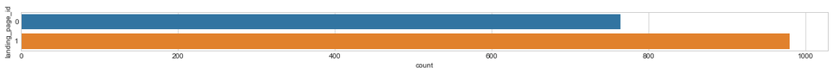

```python
fig = plt.figure(figsize=(20,1))
sns.countplot(y='landing_page_id', data=df);
print(df.landing_page_id.value_counts())
```

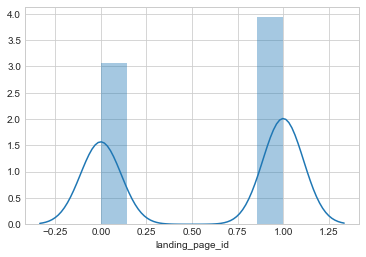

```python
sns.distplot(df.landing_page_id)
```

### campaing_trafficSource_id

```python
df_bin['campaing_trafficSource_id'] = df['campaing_trafficSource_id']
df_con['campaing_trafficSource_id'] = df['campaing_trafficSource_id']
```

```
0    1520
1     224
Name: campaing_trafficSource_id, dtype: int64
```

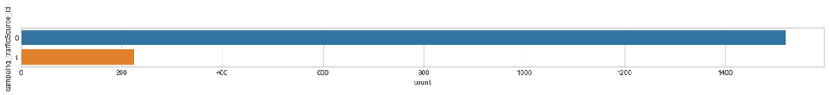

```python
fig = plt.figure(figsize=(20,1))
sns.countplot(y='campaing_trafficSource_id', data=df);
print(df.campaing_trafficSource_id.value_counts())
```

### landing_page_groups_id

```python
df_bin['landing_page_groups_id'] = df['landing_page_groups_id']
df_con['landing_page_groups_id'] = df['landing_page_groups_id']
```

```
0    1744
Name: landing_page_groups_id, dtype: int64
```

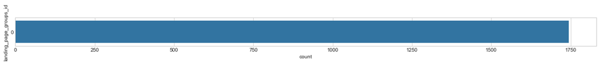

```python
fig = plt.figure(figsize=(20,1))
sns.countplot(y='landing_page_groups_id', data=df);
print(df.landing_page_groups_id.value_counts())
```

### traffic_source_id

```python
df_bin['traffic_source_id'] = df['traffic_source_id']
df_con['traffic_source_id'] = df['traffic_source_id']
```

```
0    1520
1     224
Name: traffic_source_id, dtype: int64
```

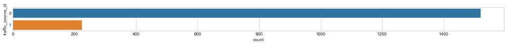

```python
fig = plt.figure(figsize=(20,1))
sns.countplot(y='traffic_source_id', data=df);
print(df.traffic_source_id.value_counts())
```

### visitor_device_browser

```python
df_bin['visitor_device_browser'] = df['visitor_device_browser']
df_con['visitor_device_browser'] = df['visitor_device_browser']
```

```
 Chrome Mobile                 489
 Mobile Safari                 454
 Edge                          297
 Samsung Browser               109
 Chrome                        106
 Unknown iOS App                94
 Facebook for iOS               62
 Internet Explorer              55
 Chrome for iOS                 26
 Safari                         20
 Firefox                         9
 News                            5
 LinkedIn for iOS                3
 Firefox for Mobile              3
 Web Light                       3
 MIUI Browser                    2
 Flipboard                       1
 Yandex.Browser for Windows      1
 Edge Mobile                     1
 Opera Mobile                    1
 Edge for iOS                    1
 Kindle-Silk                     1
 Facebook for Android            1
Name: visitor_device_browser, dtype: int64
```

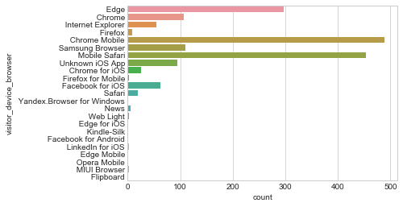

```python
sns.countplot(y='visitor_device_browser', data=df);
print(df.visitor_device_browser.value_counts())
```

### visitor_device_hardware_family

```python
df_bin['visitor_device_hardware_family'] = df['visitor_device_hardware_family']
df_con['visitor_device_hardware_family'] = df['visitor_device_hardware_family']
```

```
Emulator                     455
iPhone                       409
iPad                         174
Galaxy S8                     30
Macintosh                     27
Galaxy S7                     17
Galaxy S9                     17
Galaxy J4+                    17
Galaxy J3                     16
Galaxy S7 Edge                16
Galaxy A3                     15
P smart                       14
Galaxy S8+                    14
iPhone 7                      13
Galaxy S9+                    12
Galaxy J6 (2018) Dual SIM     12
Galaxy S10+                   12
Galaxy Tab A                  12
Galaxy A5                     11
Generic Android               10
Galaxy J3 (2017)              10
P20 Pro                       10
Xperia XA1                     9
Galaxy S6                      9
Xperia XA2                     8
P smart 2019                   8
Galaxy Tab E 9.6 WiFi          8
Galaxy S6 Edge                 8
Mate 20 lite                   8
Galaxy Tab A 2016 10.1         7
                            ...
Moto C                         1
Galaxy Tab S 10.5              1
Xperia L2                      1
8030                           1
iPad mini 3                    1
Razer Phone 2                  1
Leon                           1
iPad Pro 9.7                   1
Xperia XA1 Ultra               1
MediaPad T1 7.0                1
iPad 4                         1
P30 lite                       1
SM-J710F                       1
Galaxy Alpha                   1
iPhone 5c                      1
Galaxy A10                     1
Pixi 3 10                      1
Nexus 5X                       1
Galaxy J2 Pro                  1
Liquid E3                      1
Nokia 6                        1
MI MIX 2                       1
Xperia Z                       1
Galaxy Xcover 4                1
5                              1
Galaxy Tab S4                  1
Hot 6                          1
Acer Windows Desktop           1
K4                             1
Honor 9                        1
Name: visitor_device_hardware_family, Length: 232, dtype: int64
```

[figure not shown]

```python
sns.countplot(y='visitor_device_hardware_family', data=df);
print(df.visitor_device_hardware_family.value_counts())
```

### visitor_device_hardware_model

```python
df_bin['visitor_device_hardware_model'] = df['visitor_device_hardware_model']
df_con['visitor_device_hardware_model'] = df['visitor_device_hardware_model']
```

```
Unknown            456
iPhone             409
iPad               174
SM-G950F            29
Macintosh           27
SM-J415FN           17
SM-G930F            17
SM-G960F            16
SM-J320FN           16
SM-G935F            15
FIG-LX1             14
SM-A320FL           14
SM-G955F            14
iPhone 7            13
SM-J600FN           12
SM-G965F            12
SM-G975F            12
SM-J330FN           10
Generic Android     10
SM-A520F            10
G3121                9
SM-G920F             9
CLT-L09              9
POT-LX1              8
SM-G925F             8
H3113                8
SNE-LX1              8
SM-T560              8
SM-T580              7
SM-G900F             6
                  ...
SM-T365              1
SM-T800              1
SM-A705FN            1
SM-A310F             1
E2303                1
VF-1497              1
5099Y                1
SM-T700              1
SM-G388F             1
SM-G800F             1
Redmi 6              1
SM-A202F             1
T1-701U              1
V10                  1
SM-G935U             1
SM-T813              1
B3-A40               1
A1893                1
H3311                1
ALE-L21              1
SM-T820              1
SM-A300FU            1
H9436                1
MSW_BT767QC8TN       1
MRD-LX1              1
SM-J400F             1
V0800                1
GT-I9505             1
SM-G390F             1
GT-P5210             1
Name: visitor_device_hardware_model, Length: 252, dtype: int64
```

[figure not shown]

```python
sns.countplot(y='visitor_device_hardware_model', data=df);
print(df.visitor_device_hardware_model.value_counts())
```

### visitor_device_hardware_vendor

```python
df_bin['visitor_device_hardware_vendor'] = df['visitor_device_hardware_vendor']
df_con['visitor_device_hardware_vendor'] = df['visitor_device_hardware_vendor']
```

```
Apple                672
Unknown              467
Samsung              342
Huawei                95
Sony                  58
LG                    17
Motorola              17
Lenovo                16
HMD Global            10
Google                 6
Oneplus                6
Xiaomi                 5
Vodafone               5
Acer                   3
NUU Mobile             3
ALCATEL                2
Hipstreet              2
ALCATEL ONE TOUCH      2
Virgin Media           1
Asus                   1
EE                     1
Mikona                 1
Amazon                 1
Microsoft              1
IMO                    1
ZTE                    1
OUKITEL                1
Infinix                1
Razer                  1
STK                    1
JIAKE                  1
Doro                   1
KRAMER                 1
Wiko                   1
Name: visitor_device_hardware_vendor, dtype: int64
```

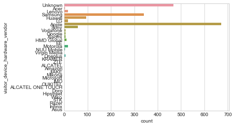

```python
sns.countplot(y='visitor_device_hardware_vendor', data=df);
print(df.visitor_device_hardware_vendor.value_counts())
```

### visitor_device_os_family

```python
df_bin['visitor_device_os_family'] = df['visitor_device_os_family']
df_con['visitor_device_os_family'] = df['visitor_device_os_family']
```

```
iOS              645
Android          610
Windows          454
macOS             23
ChromeOS           7
Mac OS X           4
Windows Phone      1
Name: visitor_device_os_family, dtype: int64
```

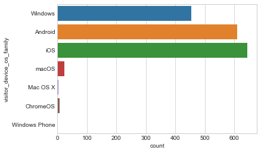

```python
sns.countplot(y='visitor_device_os_family', data=df);
print(df.visitor_device_os_family.value_counts())
```

### visitor_device_os_vendor

```python
df_bin['visitor_device_os_vendor'] = df['visitor_device_os_vendor']
df_con['visitor_device_os_vendor'] = df['visitor_device_os_vendor']
```

```
 Apple        672
 Google       617
 Microsoft    455
Name: visitor_device_os_vendor, dtype: int64
```

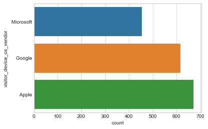

```python
sns.countplot(y='visitor_device_os_vendor', data=df);
print(df.visitor_device_os_vendor.value_counts())
```

### visitor_device_os_version

```python
df_bin['visitor_device_os_version'] = df['visitor_device_os_version']
df_con['visitor_device_os_version'] = df['visitor_device_os_version']
```

```
 12.3.1     450
 10.0       378
 9.0        213
 8.0        134
 8.1         79
 7.0         61
7            52
 12.2        40
 6.0.1       32
 10.3.3      32
 5.1.1       29
 12.3.2      26
 12.3        25
 7.1.1       23
 11.4.1      13
 6.0         12
 4.4.2       10
 12.1.4       9
 5.0.2        9
 5.1          9
 10.14.5      8
 4.4.4        8
 9.3.5        7
 10.13.6      7
 74.0         6
 12.1.1       6
 12.1         5
 5.0.1        4
 12.1.2       4
 XP           3
 4.2.1        3
 11.4         3
 10.10.5      3
 12.0.1       3
 10.3.1       3
 5.0          2
 10.12.6      2
 10.14.4      2
 12.1.3       2
 11.3.1       2
 10.14.3      2
 10.2.1       2
 12.0         2
 11.1.2       2
 4.2.2        2
 Vista        2
 10.11.6      1
 11.0.3       1
 10.0.2       1
 10.13.4      1
 11.0         1
 10.14.1      1
 11.3         1
 72.0         1
 10.3.2       1
 7.0.3        1
 11.2.6       1
 9.2          1
 11.2.5       1
Name: visitor_device_os_version, dtype: int64
```

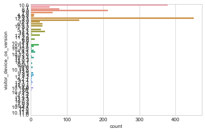

```python
sns.countplot(y='visitor_device_os_version', data=df);
print(df.visitor_device_os_version.value_counts())
```

### visitor_device_type

```python
df_bin['visitor_device_type'] = df['visitor_device_type']
df_con['visitor_device_type'] = df['visitor_device_type']
```

```
Phone      985
Desktop    488
Tablet     271
Name: visitor_device_type, dtype: int64
```

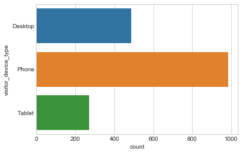

```python
sns.countplot(y='visitor_device_type', data=df);
print(df.visitor_device_type.value_counts())
```

### visitor_geo_location_cityName

```python
df_bin['visitor_geo_location_cityName'] = df['visitor_geo_location_cityName']
df_con['visitor_geo_location_cityName'] = df['visitor_geo_location_cityName']
```

```
 London                 104
 Glasgow                 64
 Birmingham              38
 Bristol                 36
 Nottingham              28
 Manchester              27
 Liverpool               25
 Leeds                   24
 Edinburgh               19
 Brighton                17
 Croydon                 17
 Belfast                 16
 Southampton             16
 Hounslow                16
 Sheffield               16
 Newcastle upon Tyne     15
 Norwich                 15
 Coventry                14
 Bradford                13
 Leicester               13
 Aberdeen                13
 Greenwich               13
 Milton Keynes           12
 Swindon                 11
 Northampton             11
 New Milton              11
 Cardiff                 11
 Stoke-on-Trent          11
 Hull                    10
 Bolton                  10
                       ...
 Golders Green            1
 Sittingbourne            1
 Magherafelt              1
 Lanark                   1
 Carrickfergus            1
 Weybridge                1
 Durham                   1
 Wotton-under-Edge        1
 Chipping Campden         1
 Bonnybridge              1
 Wallingford              1
 Virginia Water           1
 Fairlight                1
 Peacehaven               1
 Worcester                1
 Wokingham                1
 Battle                   1
 Beckenham                1
 Preesall                 1
 Lowestoft                1
 Holmesfield              1
 Enniskillen              1
 Totnes                   1
 Kirkwall                 1
 Norwood                  1
 Southam                  1
 Falmouth                 1
 Bury                     1
 East Retford             1
 Abercynon                1
Name: visitor_geo_location_cityName, Length: 535, dtype: int64
```

[figure not shown]

```python
sns.countplot(y='visitor_geo_location_cityName', data=df);
print(df.visitor_geo_location_cityName.value_counts())
```

### visitor_geo_location_connection_type

```python
df_bin['visitor_geo_location_connection_type'] = df['visitor_geo_location_connection_type']
df_con['visitor_geo_location_connection_type'] = df['visitor_geo_location_connection_type']
```

```
 Cable/DSL    1519
 Cellular      215
 Corporate      10
Name: visitor_geo_location_connection_type, dtype: int64
```

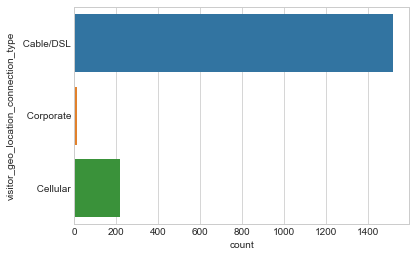

```python
sns.countplot(y='visitor_geo_location_connection_type', data=df);
print(df.visitor_geo_location_connection_type.value_counts())
```

### visitor_geo_location_countryCode

```python
df_bin['visitor_geo_location_countryCode'] = df['visitor_geo_location_countryCode']
df_con['visitor_geo_location_countryCode'] = df['visitor_geo_location_countryCode']
```

```
 GB    1744
Name: visitor_geo_location_countryCode, dtype: int64
```

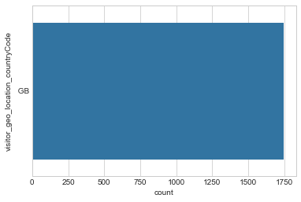

```python
sns.countplot(y='visitor_geo_location_countryCode', data=df);
print(df.visitor_geo_location_countryCode.value_counts())
```

### visitor_geo_location_isp

```python
df_bin['visitor_geo_location_isp'] = df['visitor_geo_location_isp']
df_con['visitor_geo_location_isp'] = df['visitor_geo_location_isp']
```

```
 BT                                         417
 Sky Broadband                              397
 Virgin Media                               344
 TalkTalk                                   174
 EE Mobile                                  108
 Three                                       71
 EE High Speed Internet                      50
 Plusnet                                     34
 Vodafone Limited                            31
 Daisy Communications Ltd                    21
 Kcom                                        10
 Post Office Broadband                        8
 Vodafone Broadband                           7
 Eclipse Internet                             6
 Zen Internet Ltd                             6
 Demon Internet                               4
 Hyperoptic Ltd                               3
 CustodianDC Limited                          2
 Exponential-e                                2
 The Cloud Networks Limited                   2
 Virgin Media Business                        2
 Jisc Services Limited                        2
 Forcepoint Cloud                             2
 Messagelabs Limited                          2
 BT Americas                                  2
 Zscaler                                      2
 Lycatel Distribution Uk Limited              2
 Amazon.com                                   1
 Quickline Communications Limited             1
 Telefonica O2 UK                             1
 Verizon Business                             1
 Scotnet.co.uk                                1
 Guys and St Thomas NHS Foundation Trust      1
 COLT Technology Services Group Limited       1
 Kencomp Internet                             1
 Gamma Telecom Holdings Ltd                   1
 Daisy Data Centre Solutions Limited          1
 Gigaclear PLC                                1
 Convergence (Group Networks) Limited         1
 Timico Limited                               1
 Netservers Limited                           1
 Skandia Life Business Services Limited       1
 University of Southampton                    1
 Onyx Internet Ltd                            1
 Cogent Communications Group                  1
 Entanet                                      1
 Oxford University                            1
 Independent Fibre Networks Limited           1
 WiSpire Limited                              1
 SystemIP. Ltd                                1
 Odyssey Systems Ltd                          1
 ICUK Computing Services Limited              1
 Be Un Limited                                1
 SSE PLC                                      1
 Block Solutions Ltd                          1
 University of Newcastle upon Tyne            1
 ITS Technology Group Limited                 1
 A&F Networks B.V.                            1
 Atlas Communications (NI) Ltd                1
 Infinity Developments Limited                1
Name: visitor_geo_location_isp, dtype: int64
```

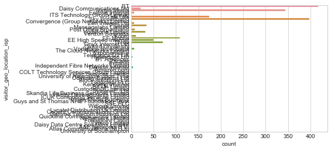

```python
sns.countplot(y='visitor_geo_location_isp', data=df);
print(df.visitor_geo_location_isp.value_counts())
```

### Exploración de datos: Bivariantes

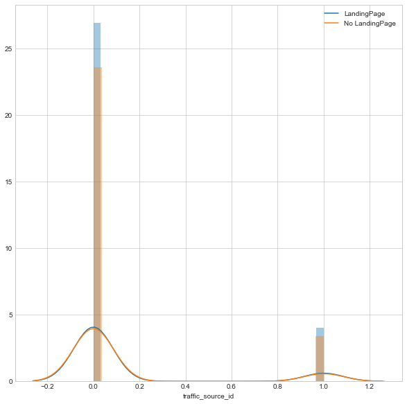

```python
# ¿Cómo se ve la variable traffic_source_id en comparación con landing_page_id?
fig = plt.figure(figsize=(10, 10))
sns.distplot(df.loc[df['landing_page_id'] == 1]['traffic_source_id'], kde_kws={'label': 'LandingPage'});
sns.distplot(df.loc[df['landing_page_id'] == 0]['traffic_source_id'], kde_kws={'label': 'No LandingPage'});
```

```python
# Función para crear visualizaciones de conteo y distribución

def plot_count_dist(data, bin_df, label_column, target_column, figsize=(20, 5), use_bin_df=False):
    """
    Función para trazar recuentos y distribuciones de una variable de etiqueta y
    variable objetivo de lado a lado.
    ::param_data:: = marco de datos de destino
    ::param_bin_df:: = trama de datos agrupada para plot de cuenta
    ::param_label_column:: = columna etiquetada binaria
    ::param_target_column:: = columna que desea ver recuentos y distribuciones
    ::param_figsize:: = tamaño de la figura (ancho, alto)
    ::param_use_bin_df:: = si se usa o no bin_df, predeterminado False
    """
    if use_bin_df:
        fig = plt.figure(figsize=figsize)
        plt.subplot(1, 2, 1)
        sns.countplot(y=target_column, data=bin_df);
        plt.subplot(1, 2, 2)
        sns.distplot(data.loc[data[label_column] == 1][target_column],
                     kde_kws={"label": "LandingPage"});
        sns.distplot(data.loc[data[label_column] == 0][target_column],
                     kde_kws={"label": "No LandingPage"});
    else:
        fig = plt.figure(figsize=figsize)
        plt.subplot(1, 2, 1)
        sns.countplot(y=target_column, data=data);
        plt.subplot(1, 2, 2)
        sns.distplot(data.loc[data[label_column] == 1][target_column],
                     kde_kws={"label": "LandingPage"});
        sns.distplot(data.loc[data[label_column] == 0][target_column],
                     kde_kws={"label": "No LandingPage"});
```

```python
# Tabulación cruzada entre traffic_source_id  y landing_page_id
pd.crosstab(df['traffic_source_id'],df['landing_page_id'], margins=True)
```

| landing_page_id traffic_source_id | 0 | 1 | All |
| --- | --- | --- | --- |
| 0 | 668 | 852 | 1520 |
| 1 | 96 | 128 | 224 |
| All | 764 | 980 | 1744 |

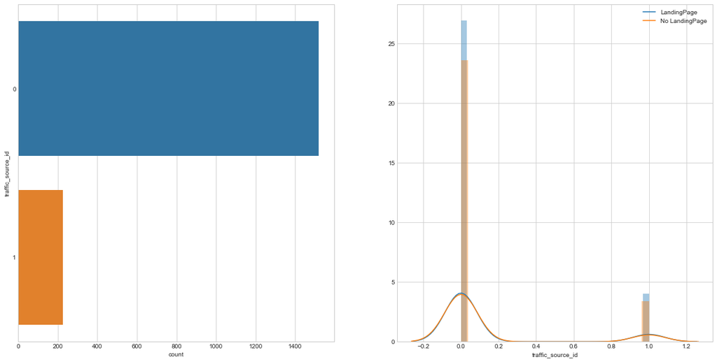

```python
# Visualice los recuentos de la variable traffic_source_id y la distribución de los valores landing_page_id
# haciendo uso de la funcion arriba mencionada

plot_count_dist(df,
                bin_df=df_bin,
                label_column='landing_page_id',
                target_column='traffic_source_id',
                figsize=(20, 10))
```

### Codificación de funciones

Ahora tenemos listos nuestros dos subtramas de datos. Podemos codificar las funciones para que estén listas para ser utilizadas con nuestros modelos de aprendizaje automático.

Codificaremos nuestra trama de datos agrupados (df_bin) con codificación de uno en caliente y nuestra trama de datos continua (df_con) con la función de codificación de etiquetas de sklearn.

Recuerde que los algoritmos de Machine Learning realizan álgebra lineal en matrices, lo que significa que todas las características necesitan tener valores numéricos. El proceso de convertir características categóricas en valores se denomina codificación. Realicemos la codificación One-Hot y Label.

```python
# One Hot Encodes
one_hot_cols = df_bin.columns.tolist()
one_hot_cols.remove('landing_page_id')
df_bin_enc = pd.get_dummies(df_bin, columns=one_hot_cols)

df_bin_enc.head()
```

|  | landing_page_id | campaing_trafficSource_id_0 | campaing_trafficSource_id_1 | landing_page_groups_id_0 | traffic_source_id_0 | traffic_source_id_1 | visitor_device_browser_ Chrome | visitor_device_browser_ Chrome Mobile | visitor_device_browser_ Chrome for iOS | visitor_device_browser_ Edge | ... | visitor_geo_location_isp_ University of Newcastle upon Tyne | visitor_geo_location_isp_ University of Southampton | visitor_geo_location_isp_ Verizon Business | visitor_geo_location_isp_ Virgin Media | visitor_geo_location_isp_ Virgin Media Business | visitor_geo_location_isp_ Vodafone Broadband | visitor_geo_location_isp_ Vodafone Limited | visitor_geo_location_isp_ WiSpire Limited | visitor_geo_location_isp_ Zen Internet Ltd | visitor_geo_location_isp_ Zscaler |
| --- | --- | --- | --- | --- | --- | --- | --- | --- | --- | --- | --- | --- | --- | --- | --- | --- | --- | --- | --- | --- | --- |
| 0 | 1 | 1 | 0 | 1 | 1 | 0 | 0 | 0 | 0 | 1 | ... | 0 | 0 | 0 | 0 | 0 | 0 | 0 | 0 | 0 | 0 |
| 1 | 0 | 1 | 0 | 1 | 1 | 0 | 1 | 0 | 0 | 0 | ... | 0 | 0 | 0 | 0 | 0 | 0 | 0 | 0 | 0 | 0 |
| 2 | 0 | 1 | 0 | 1 | 1 | 0 | 0 | 0 | 0 | 1 | ... | 0 | 0 | 0 | 0 | 0 | 0 | 0 | 0 | 0 | 0 |
| 3 | 1 | 1 | 0 | 1 | 1 | 0 | 0 | 0 | 0 | 1 | ... | 0 | 0 | 0 | 1 | 0 | 0 | 0 | 0 | 0 | 0 |
| 4 | 1 | 1 | 0 | 1 | 1 | 0 | 0 | 0 | 0 | 1 | ... | 0 | 0 | 0 | 0 | 0 | 0 | 0 | 0 | 0 | 0 |

5 rows × 1218 columns

```python
# Label Encode
df_con_enc = df_con.apply(LabelEncoder().fit_transform)
df_con_enc.head()
```

|  | landing_page_id | campaing_trafficSource_id | landing_page_groups_id | traffic_source_id | visitor_device_browser | visitor_device_hardware_family | visitor_device_hardware_model | visitor_device_hardware_vendor | visitor_device_os_family | visitor_device_os_vendor | visitor_device_os_version | visitor_device_type | visitor_geo_location_cityName | visitor_geo_location_connection_type | visitor_geo_location_countryCode | visitor_geo_location_isp |
| --- | --- | --- | --- | --- | --- | --- | --- | --- | --- | --- | --- | --- | --- | --- | --- | --- |
| 0 | 1 | 0 | 0 | 0 | 3 | 11 | 218 | 28 | 3 | 2 | 0 | 0 | 202 | 0 | 0 | 3 |
| 1 | 0 | 0 | 0 | 0 | 0 | 11 | 218 | 28 | 3 | 2 | 58 | 0 | 266 | 0 | 0 | 3 |
| 2 | 0 | 0 | 0 | 0 | 3 | 11 | 218 | 28 | 3 | 2 | 0 | 0 | 444 | 0 | 0 | 11 |
| 3 | 1 | 0 | 0 | 0 | 3 | 11 | 218 | 28 | 3 | 2 | 0 | 0 | 132 | 0 | 0 | 53 |
| 4 | 1 | 0 | 0 | 0 | 3 | 11 | 218 | 28 | 3 | 2 | 0 | 0 | 48 | 0 | 0 | 16 |

```python
# Tabulación cruzada entre visitor_device_os_vendor  y landing_page_id
pd.crosstab(df['visitor_device_os_vendor'],df['landing_page_id'], margins=True)
```

| landing_page_id visitor_device_os_vendor | 0 | 1 | All |
| --- | --- | --- | --- |
| Apple | 303 | 369 | 672 |
| Google | 254 | 363 | 617 |
| Microsoft | 207 | 248 | 455 |
| All | 764 | 980 | 1744 |

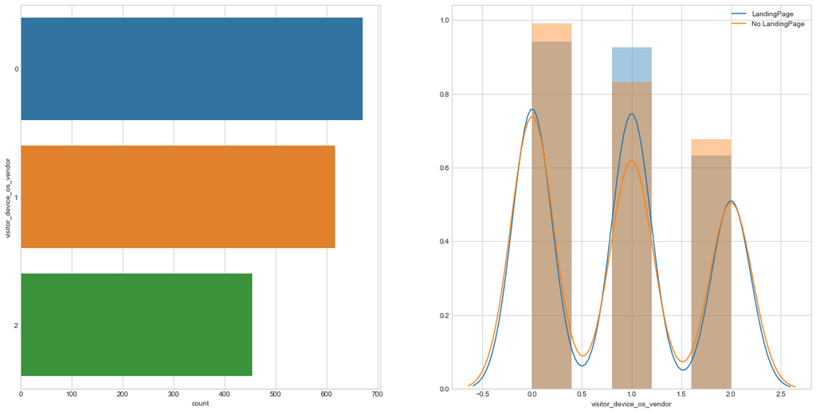

```python
plot_count_dist(df_con_enc,
                bin_df=df_bin,
                label_column='landing_page_id',
                target_column='visitor_device_os_vendor',
                figsize=(20, 10))
```

```python
# Tabulación cruzada entre visitor_device_hardware_vendor y landing_page_id
pd.crosstab(df['visitor_device_hardware_vendor'],df['landing_page_id'], margins=True)
```

| landing_page_id visitor_device_hardware_vendor | 0 | 1 | All |
| --- | --- | --- | --- |
| ALCATEL | 2 | 0 | 2 |
| ALCATEL ONE TOUCH | 0 | 2 | 2 |
| Acer | 1 | 2 | 3 |
| Amazon | 0 | 1 | 1 |
| Apple | 303 | 369 | 672 |
| Asus | 0 | 1 | 1 |
| Doro | 1 | 0 | 1 |
| EE | 1 | 0 | 1 |
| Google | 3 | 3 | 6 |
| HMD Global | 6 | 4 | 10 |
| Hipstreet | 0 | 2 | 2 |
| Huawei | 41 | 54 | 95 |
| IMO | 0 | 1 | 1 |
| Infinix | 1 | 0 | 1 |
| JIAKE | 0 | 1 | 1 |
| KRAMER | 0 | 1 | 1 |
| LG | 8 | 9 | 17 |
| Lenovo | 6 | 10 | 16 |
| Microsoft | 1 | 0 | 1 |
| Mikona | 0 | 1 | 1 |
| Motorola | 5 | 12 | 17 |
| NUU Mobile | 2 | 1 | 3 |
| OUKITEL | 0 | 1 | 1 |
| Oneplus | 3 | 3 | 6 |
| Razer | 0 | 1 | 1 |
| STK | 0 | 1 | 1 |
| Samsung | 140 | 202 | 342 |
| Sony | 25 | 33 | 58 |
| Unknown | 210 | 257 | 467 |
| Virgin Media | 1 | 0 | 1 |
| Vodafone | 3 | 2 | 5 |
| Wiko | 0 | 1 | 1 |
| Xiaomi | 1 | 4 | 5 |
| ZTE | 0 | 1 | 1 |
| All | 764 | 980 | 1744 |

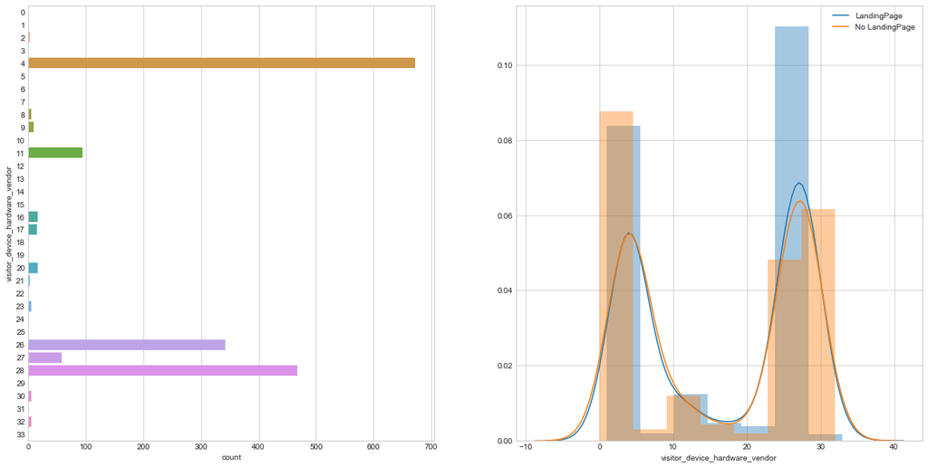

```python
plot_count_dist(df_con_enc,
                bin_df=df_bin,
                label_column='landing_page_id',
                target_column='visitor_device_hardware_vendor',
                figsize=(20, 10))
```

### Correlación de variables

La correlación es una medida de cuánto cambian juntas dos variables aleatorias. Las funciones no deberían estar correlacionadas entre sí y estar altamente correlacionadas con la función que estamos tratando de predecir.

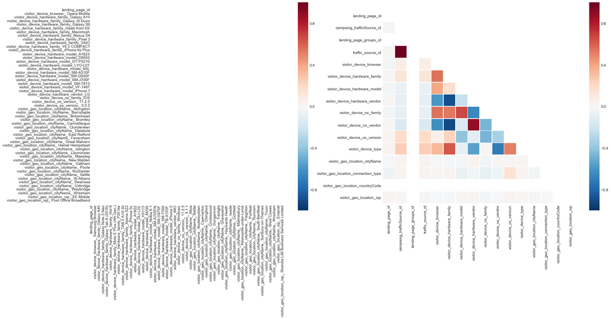

```python
# Matriz de Correlación
plt.style.use('seaborn-whitegrid')
fig = plt.figure(figsize=(25,10))

plt.subplot(1, 2, 1)
# Generate a mask for the upper triangle
mask = np.zeros_like(df_bin_enc.corr(), dtype=np.bool)
mask[np.triu_indices_from(mask)] = True
sns.heatmap(df_bin_enc.corr(),
            vmin=-1, vmax=1,
            square=True,
            cmap=sns.color_palette("RdBu_r", 100),
            mask=mask,
            linewidths=.5);

plt.subplot(1, 2, 2)
# Generate a mask for the upper triangle
mask = np.zeros_like(df_con_enc.corr(), dtype=np.bool)
mask[np.triu_indices_from(mask)] = True
sns.heatmap(df_con_enc.corr(),
            vmin=-1, vmax=1,
            square=True,
            cmap=sns.color_palette("RdBu_r", 100),
            mask=mask,
            linewidths=.5);
```

### Reducción / selección de funciones

Una vez que tengamos nuestras funciones listas para usar, podríamos encontrar que la cantidad de funciones disponibles es demasiado grande para que nuestros algoritmos de aprendizaje automático la puedan ejecutar en un plazo razonable. Tenemos varias opciones disponibles para la reducción de funciones y la selección de funciones.

• Reducción de dimensionalidad: Análisis de componentes principales (PCA): el análisis de componentes principales (PCA) es un procedimiento estadístico que utiliza una transformación ortogonal para convertir un conjunto de observaciones de variables posiblemente correlacionadas en un conjunto de valores de variables linealmente no correlacionadas llamadas componentes principales. Esta transformación se define de tal manera que el primer componente principal tiene la mayor varianza posible (es decir, representa la mayor variabilidad posible en los datos), y cada componente subsiguiente a su vez tiene la mayor varianza posible bajo la restricción que es ortogonal a los componentes anteriores.

• Descomposición de valor singular (SVD): SVD es una factorización de una matriz real o compleja. Es la generalización de la descomposición propia de una matriz normal semidefinida positiva (por ejemplo, una matriz simétrica con valores propios positivos) a cualquier matriz m × n a través de una extensión de la descomposición polar. Tiene muchas aplicaciones útiles en procesamiento de señales y estadísticas.

• Importancia / relevancia de la característica: Métodos de filtro: los métodos de tipo de filtro seleccionan características basadas solo en métricas generales como la correlación con la variable a predecir. Los métodos de filtro suprimen las variables menos interesantes. Las otras variables serán parte de una clasificación o un modelo de regresión utilizado para clasificar o predecir datos. Estos métodos son particularmente efectivos en el tiempo de cálculo y robustos para sobreajustar.

### PCA

Podemos usar PCA para reducir la cantidad de características que se utilizarán en nuestros algoritmos de ML, y graficar la variación nos da una idea de cuántas características realmente necesitamos para representar completamente nuestro conjunto de datos.

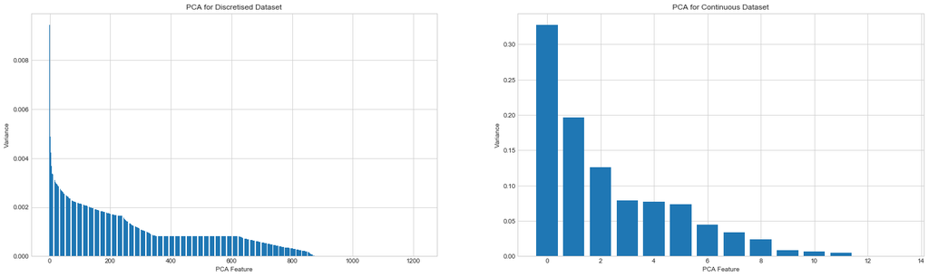

```python
std_scale = preprocessing.StandardScaler().fit(df_bin_enc.drop('landing_page_id', axis=1))
X = std_scale.transform(df_bin_enc.drop('landing_page_id', axis=1))
pca1 = PCA(n_components=len(df_bin_enc.columns)-1)
fit1 = pca1.fit(X)

std_scale = preprocessing.StandardScaler().fit(df_con_enc.drop('landing_page_id', axis=1))
X = std_scale.transform(df_con_enc.drop('landing_page_id', axis=1))
pca2 = PCA(n_components=len(df_con_enc.columns)-2)
fit2 = pca2.fit(X)

# Graphing the variance per feature
plt.style.use('seaborn-whitegrid')
plt.figure(figsize=(25,7))

plt.subplot(1, 2, 1)
plt.xlabel('PCA Feature')
plt.ylabel('Variance')
plt.title('PCA for Discretised Dataset')
plt.bar(range(0, fit1.explained_variance_ratio_.size), fit1.explained_variance_ratio_);

plt.subplot(1, 2, 2)
plt.xlabel('PCA Feature')
plt.ylabel('Variance')
plt.title('PCA for Continuous Dataset')
plt.bar(range(0, fit2.explained_variance_ratio_.size), fit2.explained_variance_ratio_);
```

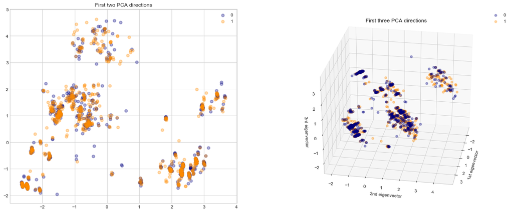

```python
# PCA's graficas en 2D and 3D
# Aplicando Escala

std_scale = preprocessing.StandardScaler().fit(df_con_enc.drop('landing_page_id', axis=1))
X = std_scale.transform(df_con_enc.drop('landing_page_id', axis=1))
y = df_con_enc['landing_page_id']

# Formatting
target_names = [0,1]
colors = ['navy','darkorange']
lw = 2
alpha = 0.3
# 2 Components PCA
plt.style.use('seaborn-whitegrid')
plt.figure(2, figsize=(20, 8))

plt.subplot(1, 2, 1)
pca = PCA(n_components=2)
X_r = pca.fit(X).transform(X)
for color, i, target_name in zip(colors, [0, 1], target_names):
    plt.scatter(X_r[y == i, 0], X_r[y == i, 1],
                color=color,
                alpha=alpha,
                lw=lw,
                label=target_name)
plt.legend(loc='best', shadow=False, scatterpoints=1)
plt.title('First two PCA directions');

# 3 Components PCA
ax = plt.subplot(1, 2, 2, projection='3d')

pca = PCA(n_components=3)
X_reduced = pca.fit(X).transform(X)
for color, i, target_name in zip(colors, [0, 1], target_names):
    ax.scatter(X_reduced[y == i, 0], X_reduced[y == i, 1], X_reduced[y == i, 2],
               color=color,
               alpha=alpha,
               lw=lw,
               label=target_name)
plt.legend(loc='best', shadow=False, scatterpoints=1)
ax.set_title("First three PCA directions")
ax.set_xlabel("1st eigenvector")
ax.set_ylabel("2nd eigenvector")
ax.set_zlabel("3rd eigenvector")

# rotate the axes
ax.view_init(30, 10)
```

### Importancia de la característica

El bosque aleatorio consta de varios árboles de decisión. Cada nodo en los árboles de decisión es una condición en una sola característica, diseñada para dividir el conjunto de datos en dos para que los valores de respuesta similares terminen en el mismo conjunto. La medida en base a la cual se elige la condición óptima (localmente) se llama impureza. Al entrenar un árbol, se puede calcular cuánto disminuye cada característica la impureza ponderada en un árbol. Para un bosque, se puede promediar la disminución de impurezas de cada característica y las características se clasifican de acuerdo con esta medida. Esta es la medida de importancia característica expuesta en las implementaciones de Random Forest de sklearn.

#### Uso del bosque aleatorio para obtener una idea de la importancia de la característica

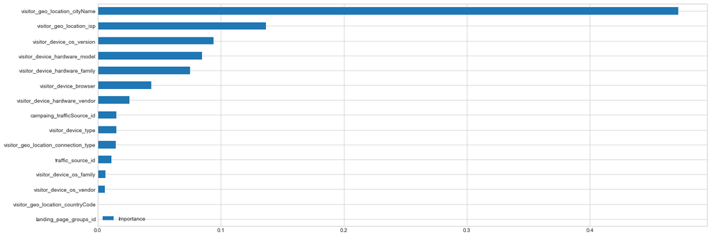

```python
clf = RandomForestClassifier()
clf.fit(df_con_enc.drop('landing_page_id', axis=1), df_con_enc['landing_page_id'])

plt.style.use('seaborn-whitegrid')
importance = clf.feature_importances_
importance = pd.DataFrame(importance, index=df_con_enc.drop('landing_page_id', axis=1).columns, columns=["Importance"])
importance.sort_values(by='Importance', ascending=True).plot(kind='barh', figsize=(20,len(importance)/2));
```

```
Feature Ranking For Non-Discretised: [1 8 1 1 4 5 1 1 1 2 1 6 1 7 3]
Optimal number of features : 8
```

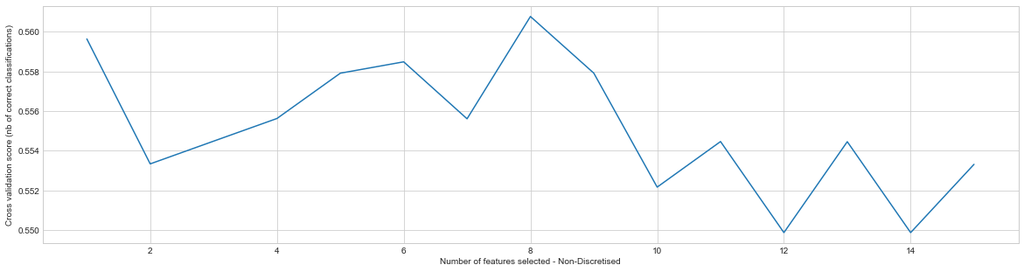

```python
# Cálculo de RFE para un conjunto de datos no discretos y representación gráfica de la importancia de cada característica, por conjunto de datos
selector1 = RFECV(LogisticRegression(), step=1, cv=5, n_jobs=-1)
selector1 = selector1.fit(df_con_enc.drop('landing_page_id', axis=1).values, df_con_enc['landing_page_id'].values)
print("Feature Ranking For Non-Discretised: %s" % selector1.ranking_)
print("Optimal number of features : %d" % selector1.n_features_)
# Plot number of features VS. cross-validation scores
plt.style.use('seaborn-whitegrid')
plt.figure(figsize=(20,5))
plt.xlabel("Number of features selected - Non-Discretised")
plt.ylabel("Cross validation score (nb of correct classifications)")
plt.plot(range(1, len(selector1.grid_scores_) + 1), selector1.grid_scores_);

# Feature space could be subsetted like so:
df_con_enc = df_con_enc[df_con_enc.columns[np.insert(selector1.support_, 0, True)]]
```

### Consideraciones:

• Realizar Ingeniera de Características a las variables : visitor_device_browser, visitor_device_hardware_family, visitor_device_hardware_model, visitor_device_hardware_vendor, visitor_device_os_version, visitor_geo_location_cityName, visitor_geo_location_isp, ya que nos va permitir mejorar las métricas a considerar en el estudio, es decir, se va aumentar el accuracy, disminuye el loos

• Dado que son variables categóricas es recomendable realizar un estudio mediante, técnicas de Regresión Logística, aplicando Tensorflow.

• Es importante también realizar otros tipos de algoritmos de Machine Learning (ML), tales como: k-Nearest Neighbors, Gaussian Naive Bayes, Linear SVC, Stochastic Gradient Descent, Decision Tree Classifier, Random Forest Classifier, Gradient Boosting Trees, entre otras. Realizar validación cruzada, competir los diferentes modelos y selección el que mayor accuracy nos genere.